# D3mirt: Descriptive Three-Dimensional Multidimensional Item Response Theory for R

13 March 2024

# Summary

`D3mirt` package for `R` (R Core Team 2021) offers functions for analyzing questionnaire items used in psychological research in a three-dimensional latent space. The application is based on descriptive multidimensional item response theory (DMIRT) (Reckase, M. D. 2009; Reckase 1985; Reckase and McKinley 1991), a statistical framework that incorporates vector geometry to describe item characteristics. The method is foremost visual and the latent model can be plotted as an interactive graphical device with the help of a dedicated plot function based on `RGL` 3D visualization device system for `R` (Adler and Murdoch 2023). Alongside the plot function, the package also includes a dedicated model identification function that helps the user identify the DMIRT model and a model estimation function for extracting the necessary vector estimates. New additions to the DMIRT framework introduced in the `D3mirt` package include the option of studying constructs (explained below) and individual scores plotted in the three-dimensional latent model.

# Statement of need

Common to most item response theory (IRT) models is the assumption of *unidimensionality*, i.e., that a test or item measures simple structures (Hambleton and Rogers 1991). There are, however many occasions where this may be improper. Consider a mathematical word problem (Reckase, M. D. 2009; Reckase 1985; Reckase and McKinley 1991). To solve a mathematical word problem, one must often have both verbal and mathematical skills, refereed to as abilities (denoted $\theta$) in the literature on IRT. In other words, one’s resulting answer would be a function based on one’s ability to read, on the one hand, and one’s ability to perform numerical manipulations, on the other. Accordingly, instead of a person’s location on a unidimensional latent variable, the mathematical word problem illustrates a situation where it seems more reasonable to assume that a correct response is due to the respondent’s location in a multidimensional latent variable space.

Descriptive multidimensional item response theory (DMIRT) (Reckase, M. D. 2009; Reckase 1985; Reckase and McKinley 1991) has been proposed as a data reduction technique for the just mentioned situation. The method is based on using a *compensatory model*, i.e., a type of measurement model within multidimensional IRT that uses linear combinations of $\theta$-values for ability assessment. Accordingly, in this type of model it assumed that the same probability score for a correct response can be reached by adding different combinations of $\theta$-values. In turn, this implies that the compensatory model allows items to be unidimensional, i.e., that they measures a single ability, or *within-multidimensional*, i.e., that the items measures more than one ability in the model space.

Note, the `D3mirt` approach is limited to two types of compensatory models, dependent on item type. If dichotomous items are used, the analysis is based on the multidimensional extension of the two-parameter logistic model (McKinley and Reckase 1983) as the compensatory model. If polytomous items are used, the analysis is based on the two-parameter multidimensional graded response model (Muraki and Carlson 1995) as the compensatory model.

Compared to other software, `D3mirt` is unique in implementing DMIRT methodology explicitly and comprehensively in a three-dimensional interactive environment. For instance, the compensatory model can be fitted with software dedicated to multidimensional IRT that supports dichotomous or polytomous data and that allows the user to specify the necessary factor structure. This includes software such as `Mplus` (Muthén and Muthén 1998-2017) or `IRTPRO 2.1` (Thissen and du Toit 2011) and `flexMIRT` (Houts and Cai 2020) for the Windows environment. Using these software programs, the DMIRT estimates can then be derived manually with the help of general mathematical software, such as `MATLAB` (MATLAB 2022) or `Mathematica` (Mathematica 2023), and plotted with built-in options for creating vector plots in two or three-dimensions. This is, however, often time-consuming, and the plotting methods are not optimized for DMIRT analysis and for test development. Regarding `R`, the `mirt` package (Chalmers 2012) can be used to fit the compensatory multidimensional model and derive the basic DMIRT item and person parameters whuile the vector plot options are limited. There is also the `R` package `plink` (Weeks 2010) that offers two-dimensional vector plots suitable for DMIRT analysis but only for dichotomous items. Another more general limitation is that none of the formerly mentioned software applications offers a function that can help identify the DMIRT model. The user is, therefore, left to a process of trial and error.

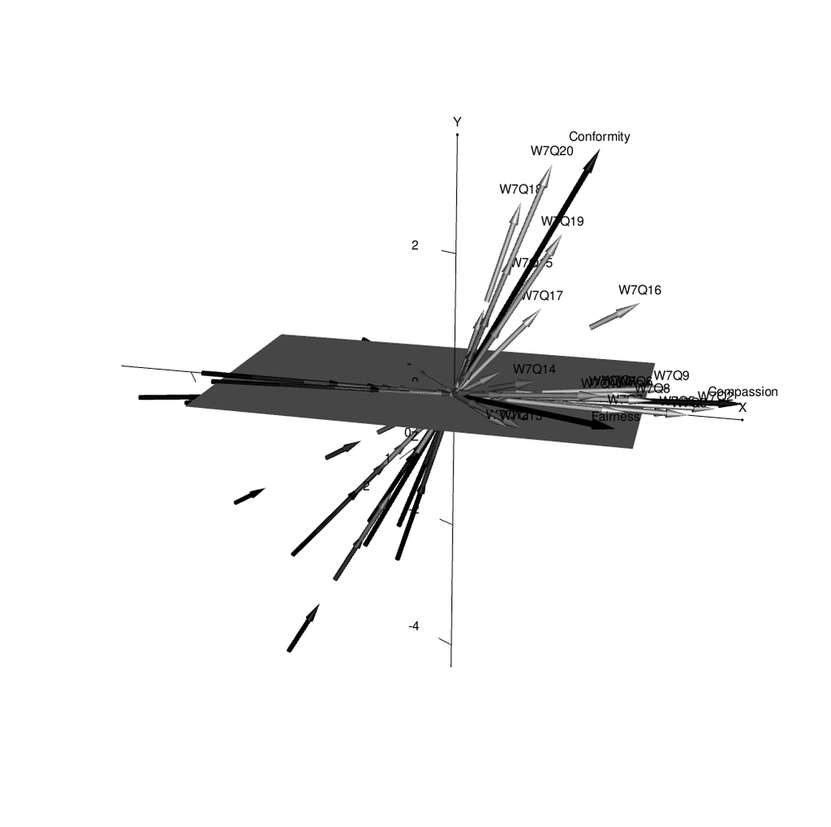

**Figure 1**. A still shot of the graphical output from `D3mirt`. The Figure illustrates a three-dimensional vector plot for items in the `anes0809offwaves` data set included in the package. The output also shows three construct vector arrows: Compassion, Fairness, and Conformity (solid black arrows).

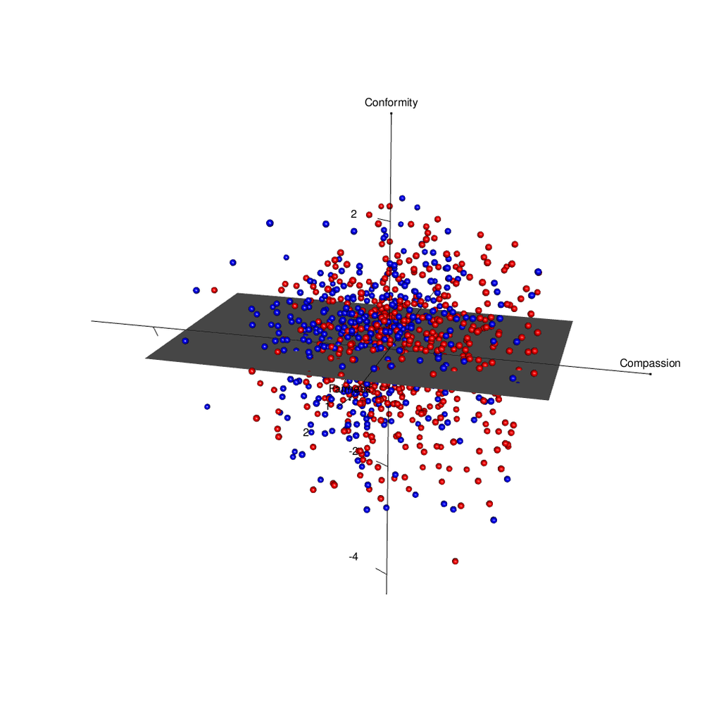

**Figure 2**. A still shot of the graphical output from `D3mirt` illustrating respondent scores in the latent space separated on sex (male in blue and female in red) from the `anes0809offwaves` data set included in the package.

# Multidimensional item parameters

The theoretical framework for DMIRT rests foremost on three assumptions (Reckase 1985). Firstly, ability maps the probability monotonically, such that a higher level of ability implies a higher probability of answering an item correctly. Second, we wish to locate an item at a singular point at which it is possible to derive item characteristics for the multidimensional case. Thirdly, an item’s maximum level of discrimination, i.e., its highest possible sensitivity score for measuring ability, is the best option for the singular point estimation. The most important parameter equations capturing the just mentioned assumptions in DMIRT will be presented below.

Firstly, by using the discrimination score $a_i$ from the compensatory model we can derive the multidimensional analog to the unidimensional discrimination parameter, i.e., the multidimensional discrimination index (MDISC), denoted $A_i$ for item $i$, to highlight the connection to the unidimensional $a_i$ parameter (Reckase, M. D. 2009; Reckase and McKinley 1991).

$$\begin{equation} \label{eq:MDISC}
MDISC = A_i = \sqrt {\sum_{k = 1}^{m} a^{2}_{ik}}
\end{equation}$$

With the slope constant $\frac{1}{4}$ omitted (Reckase, M. D. 2009; Reckase and McKinley 1991). Importantly, the MDISC sets the orientation of the item vectors in the multidimensional space (Reckase, M. D. 2009; Reckase and McKinley 1991), as follows.

$$\begin{equation} \label{eq:dcos}
\omega_{il}= cos^{-1}\left(\frac{a_{il}}{\sqrt{\sum_{k=1}^m
a^2_{ik}}}\right)
\end{equation}$$

On latent axis $l$ in the model. Note, the $\omega_{il}$ is in this solution a characteristic of the item $i$ that tells in what direction $i$ has its highest level of discrimination, assuming a multidimensional latent space (Reckase, M. D. 2009; Reckase and McKinley 1991). This gives us the following criteria to use as a rule of thumb. Assume a two-dimensional space, an orientation of $0^{\circ}$ with respect to any of the model axes indicates that the item is unidimensional. Such an item describes a singular trait only. In contrast, an orientation of $45^{\circ}$ indicated that the item is within-multidimensional. Such an item describes both traits in the two-dimensional model equally well. The same criteria are extended to the three-dimensional case. The MDISC is also used in the graphical output to scale the length of the vector arrows representing the item response functions, e.g., so that longer vector arrows indicate higher discrimination, shorter arrows lower discrimination in the model, and so on.

Next, to assess multidimensional difficulty, the distance from the origin is calculated using the multidimensional difficulty (MDIFF) index (Reckase 1985):

$$\begin{equation} \label{eq:MDIFF}
MDIFF=B_i=\frac{-d_i}{\sqrt{\sum_{k=1}^m a^2_{ik}}}
\end{equation}$$

$$\begin{equation} \label{eq:DDISC}
DDISC =\sum_{k=1}^{m}a_{ik}cos\,\omega_{ik}
\end{equation}$$

Since the DDISC is a local characteristic in the model, it is always the case that $DDISC\,\leq\,MDISC$. In `D3mirt`, the DDISC is optional and implemented in `D3mirt`as optional *construct vectors*.

# Acknowledgements

I acknowledge support, advice, and suggestions for improvements from my supervisor Dr. Anders Sjöberg, Stockholm University. I also would like to express gratitude to Dr. Fredrik Jansson, Professor Torun Lindholm Öjmyr, and Professor Mats Nilsson, Stockholm University, for their support and professional advice.

# References

Adler, D., and D. Murdoch. 2023. *Rgl: 3D Visualization Using OpenGL*. https://dmurdoch.github.io/rgl/index.html.

Chalmers, R. P. 2012. “mirt: A Multidimensional Item Response Theory Package for the R Environment.” *Journal of Statistical Software* 48 (6): 1–29. https://doi.org/10.18637/jss.v048.i06.

Forsberg, E., and A. Sjöberg. 2024. “A Validation Study of the Extended Relevance Scale using the D3mirt Package for R.” *Measurement: Interdisciplinary Research and Perspectives*, 1–23. https://doi.org/10.1080/15366367.2023.2282418.

Hambleton, Swaminathan, R. K., and H. J. Rogers. 1991. *Fundamentals of Item Response Theory*. SAGE Publications.

Houts, C. R., and L. Cai. 2020. *flexMIRT User’s Manual Version 3.52: Flexible Multilevel Multidimensional Item Analysis and Test Scoring*. Chapel Hill, NC: Vector Psychometric Group.

Mathematica. 2023. “Mathematica, Version 13.3.” Wolfram Research Inc. https://www.wolfram.com/mathematica.

MATLAB. 2022. “MATLAB Version: 9.13.0 (R2022b).” Natick, Massachusetts, United States: The MathWorks Inc. https://www.mathworks.com.

McKinley, R. L., and M. D. Reckase. 1983. “An Extension of the Two-Parameter Logistic Model to the Multidimensional Latent Space.” ONR83-2. Iowa City, IA: American College Testing Program.

Muraki, E., and J. E. Carlson. 1995. “Full-Information Factor Analysis for Polytomous Item Responses.” *Applied Psychological Measurement* 1 (19): 73–90. https://doi.org/10.1177/014662169501900109.

Muthén, L. K., and B. O. Muthén. 1998-2017. *Mplus User’s Guide. Eight Edition*. Muthén & Muthén. https://www.statmodel.com.

R Core Team. 2021. *R: A Language and Environment for Statistical Computing*. Vienna, Austria: R Foundation for Statistical Computing. https://www.R-project.org/.

Reckase, M. D. 1985. “The Difficulty of Test Items That Measure More Than One Ability.” *Applied Psychological Measurement* 4 (9): 401–12.

Reckase, M. D. 2009. *Multidimensional Item Response Theory*. Springer-Verlag. https://doi.org/10.1007/978-0-387-89976-3.

Reckase, M. D., and R. L. McKinley. 1991. “The Discriminating Power of Items That Measure More Than One Dimension.” *Applied Psychological Measurement* 4 (15): 361–73.

Thissen, C. L., and S. H. C. du Toit. 2011. *IRTPRO for Windows*. Lincolnwood, IL: Scientific Software International.

Weeks, J. P. 2010. “plink: An R Package for Linking Mixed-Format Tests Using IRT-Based Methods.” *Journal of Statistical Software* 35 (12): 1–33. http://www.jstatsoft.org/v35/i12/.